# chapter1: Generative Models for Discrete Data

roland

Mar 20, 2019

## goals for this chapter

- Learn how to obtain the probabilities of all possible outcomes from a given model and see how we can compare the theoretical frequencies with those observed in real data.
- Explore a complete example of how to use the Poisson distribution to analyse data on epitope detection.
- See how we can experiment with the most useful generative models for discrete data: Poisson, binomial, multinomial.
- Use the **R** functions for computing probabilities and counting rare events.
- Generate random numbers from specified distributions.

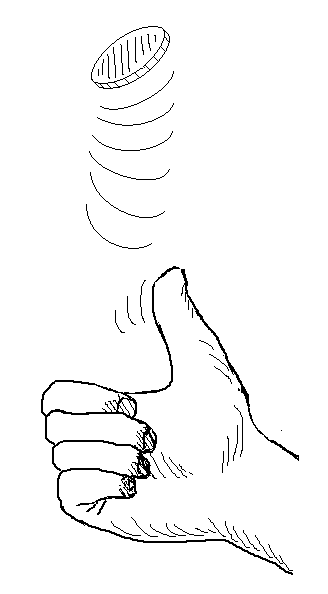

fig0: discrete data

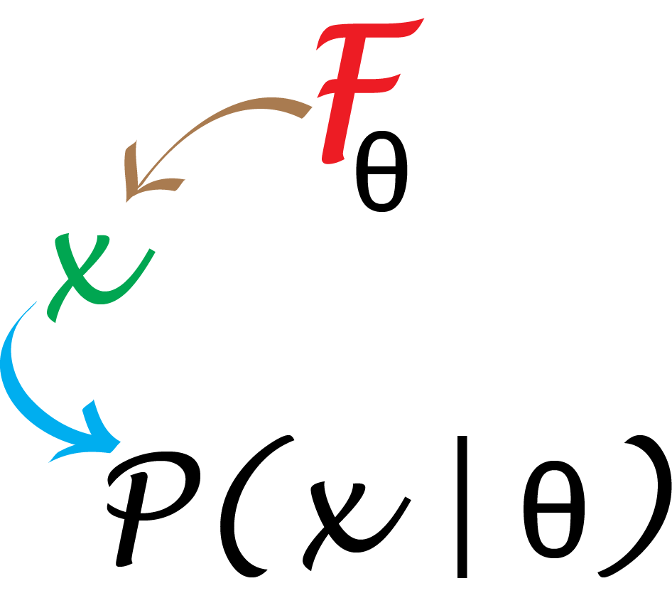

fig1: Top-down approach.

## 1. Bernoulli Trials

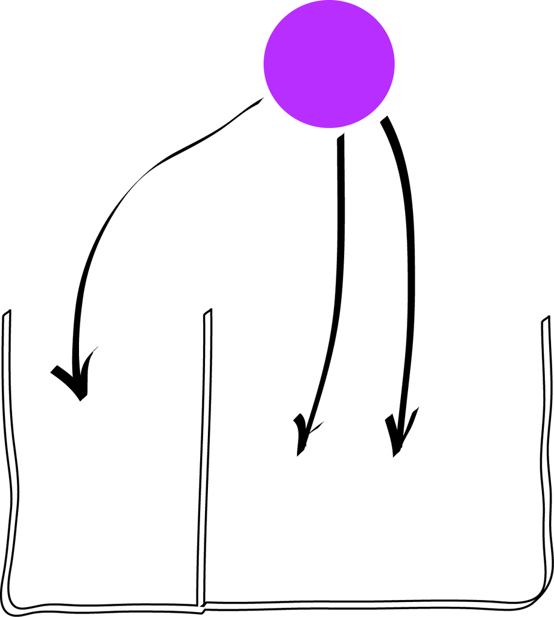

fig2: Two possible events with unequal probabilities. We model this by a Bernoulli distribution with probability parameter $p=2/3$.

```r
rbinom(12, prob = 2/3, size = 1)
```

```
 [1] 1 1 1 1 1 1 0 1 1 0 1 1
```

```r
rbinom(12, prob = 2/3, size = 1)
```

```
 [1] 0 1 1 0 1 1 1 0 1 1 0 1
```

```r
set.seed(235569515)
rbinom(1, prob = 0.3, size = 15)
```

```
[1] 5
```

```r
.freqoutcome <- (0:15)[which.max(dbinom(0:15, prob = 0.3, 15))]
.freqoutcome
```

```
[1] 4
```

```r
probabilities = dbinom(0:15, prob = 0.3, size = 15)
round(probabilities, 2)
```

```
 [1] 0.00 0.03 0.09 0.17 0.22 0.21 0.15 0.08 0.03 0.01 0.00 0.00 0.00 0.00 0.00 0.00
```

Binomial *probability mass distribution*:

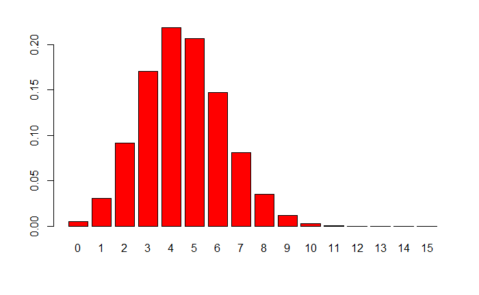

```r
barplot(probabilities, names.arg = 0:15, col = "red")
```

Theoretical distribution of $B(15,0.3)$ . The highest bar is at $x=4$. We have chosen to represent theoretical values in red throughout.

$$\begin{equation*}
\begin{aligned}
P(X=k) &=& \frac{n\times (n-1)... (n-k+1)}{k\times(k-1)... 1}\; p^k\, (1-p)^{n-k} \\
&=& \frac{n!}{(n-k)!k!}\;p^k\, (1-p)^{n-k}\\
&=& { n \choose k}\; p^k\, (1-p)^{n-k}.\end{aligned}
\end{equation*}$$

$${n \choose k}=\frac{n!}{(n-k)!k!}$$

## 1. Poissson distributions

[figure not shown]

fig2: Simeon Poisson, after whom the Poisson distribution is named.

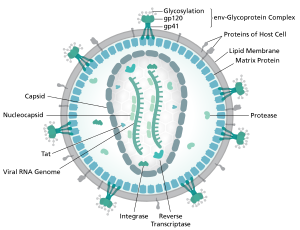

fig3: HIV virion, source: WIKIPEDIA.

We are told that mutations along the genome of HIV (Human Immunodeficiency Virus, ~10,000 bp long) occur at random with a rate of 5 in 10,000.

$$\lambda=np=10000\frac{5}{10000}=5$$

```r
dpois(x = 3, lambda = 5)
```

[output not shown]

```r
barplot(dpois(0:12, 5), names.arg = 0:12, col = "red")
```

[output not shown]

$$P(X=k)=\frac{\lambda^ke^-\lambda}{k!}$$

Poisson **probability mass distribution**:

```r
dpois(x = 3, lambda = 5)
```

```
[1] 0.1403739
```

```r
dpois(x = 0:12, lambda = 5)
```

```
 [1] 0.006737947 0.033689735 0.084224337 0.140373896 0.175467370 0.175467370 0.146222808 0.104444863 0.065278039 0.036265577
[11] 0.018132789 0.008242177 0.003434240
```

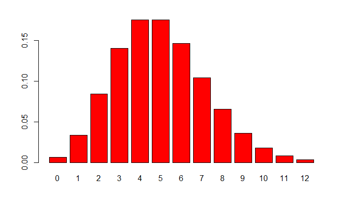

```r
barplot(dpois(0:12, 5), names.arg = 0:12, col = "red")
```

```r
rbinom(1, prob = 5e-4, size = 10000)
```

```
[1] 6
```

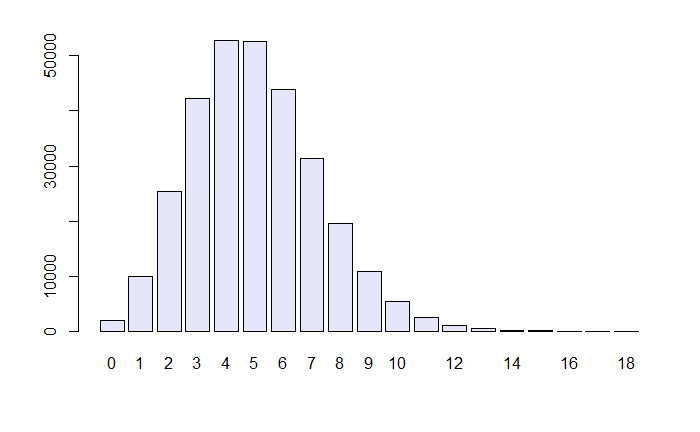

```r
simulations = rbinom(n = 300000, prob = 5e-4, size = 10000)
barplot(table(simulations), col = "lavender")
```

## use case: epitope detection

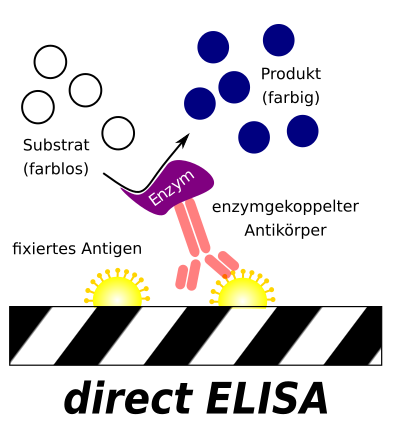

fig4: ELISA, source: WIKIPEDIA.

We’re going to study the data for all 50 patients tallied at each of the 100 positions. If there are no allergic reactions, the false positive rate means that for one patient, each individual position has a probability of 1 in 100 of being a 1. So, after tallying 50 patients, we expect at any given position the sum of the 50 observed (0,1) variables to have a Poisson distribution with parameter 0.5.

What we might encouter:

```r
`[<-`(rep(0, 100), 22, 1)
```

```
  [1] 0 0 0 0 0 0 0 0 0 0 0 0 0 0 0 0 0 0 0 0 0 1 0 0 0 0 0 0 0 0 0 0 0 0 0 0 0 0 0 0 0 0 0 0 0 0 0 0 0 0 0 0 0 0 0 0 0 0 0 0 0 0 0 0 0 0 0 0
 [69] 0 0 0 0 0 0 0 0 0 0 0 0 0 0 0 0 0 0 0 0 0 0 0 0 0 0 0 0 0 0 0 0
```

Just by chance (Poisson) we might get:

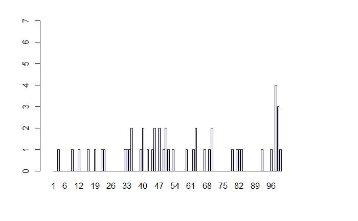

**ELISA array results** for 50 patients in the 100 positions.

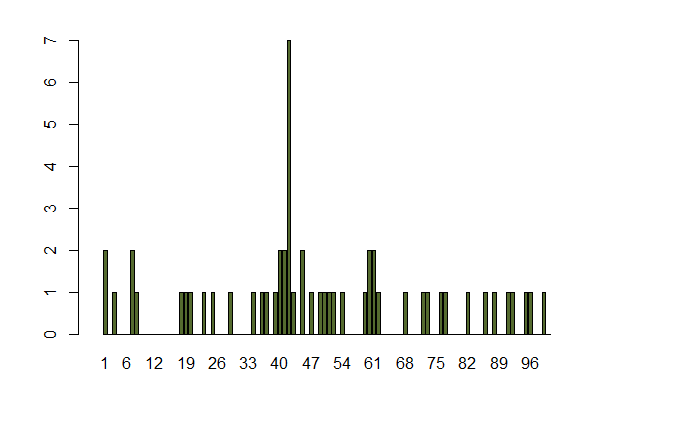

```r
load("~/projects/DataAnalysis/Uni/TopicsDataScience/TopicsInDataScienceSS19/MSMB/e100.RData")
barplot(e100, ylim = c(0, 7), width = 0.7, xlim = c(-0.5, 100.5),
        names.arg = seq(along = e100), col = "darkolivegreen")
```

What are the chances of seeing a value as large as 7, if no epitope is present?

$$\begin{equation*}
P(X\geq 7)= \sum_{k=7}^\infty P(X=k)=1-P(X\leq6)
\end{equation*}$$

```r
1 - ppois(6, 0.5)
```

```
[1] 1.00238e-06
```

```r
ppois(6, 0.5, lower.tail = FALSE)
```

```
[1] 1.00238e-06
```

Use extreme value analysis as we have to consider 100 Poisson trials, not just one:

$$\begin{equation*}
\begin{aligned}
P(x_{(100)}\geq 7)
&=&1-P(x_{(100)} \leq 6)\\
&=&1-P(x_{(1)}\leq 6 )\times P(x_{(2)}\leq 6 )\times \cdots \times P(x_{(100)} \leq 6 )\\
&=&1-P(x_1\leq 6 )\times P(x_2\leq 6 )\times \cdots \times P(x_{100}\leq 6 )\\
&=&1-\prod_{i=1}^{100} P(x_i \leq 6 )\simeq 1-(1 - 10^{-4})\end{aligned}
\end{equation*}$$

## Computing probabilities by simulation

Applying the **Monte Carlo** method to find the probabilities we are interested in.

```r
maxes = replicate(100000, {max(rpois(100, 0.5))})

table(maxes)
```

```
maxes
    1     2     3     4     5     6     7     8
   10 23458 60581 14178  1626   141     5     1
```

```r
mean( maxes >= 7 )
```

```
[1] 6e-05
```

## Multinomial distributions: the case of DNA

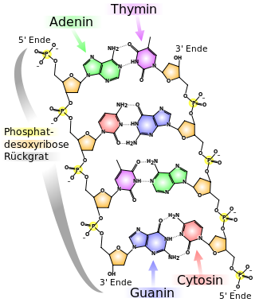

fig5: DNA. Source: WIKIPEDIA.

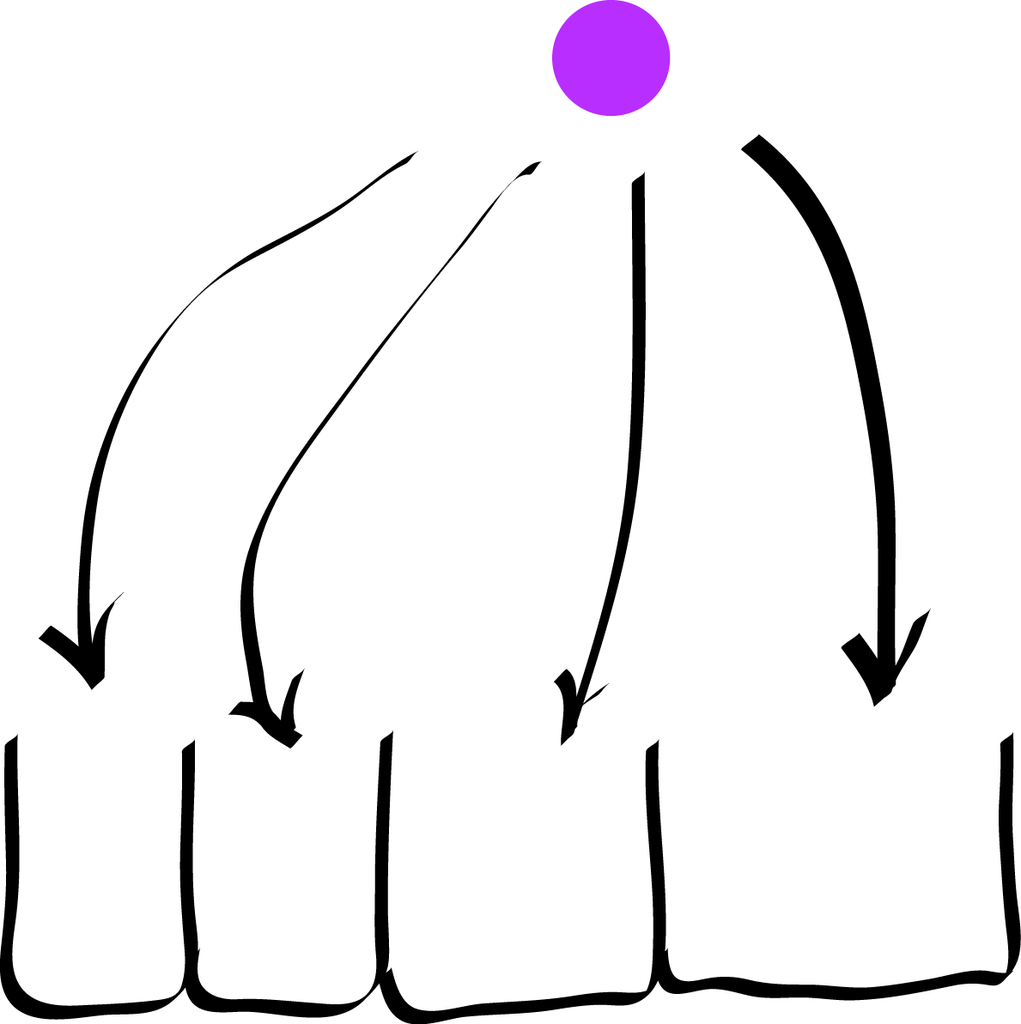

fig6: The boxes represent four outcomes or levels of a discrete **categorical** variable. The box on the right represents the more likely outcome.

$$p_A+p_C+p_G+p_T=1$$

$$\begin{equation*}
\begin{aligned}
P(x_1,x_2,...,x_m \;|\; p_1,...,p_m)
&=&\frac{n!}{\prod x_i!}\prod p_i^{x_i}\\
&=&{{n}\choose{x_1,x_2,...,x_m}} \; p_1^{x_1}\,p_2^{x_2} \cdots p_m^{x_m}.\end{aligned}
\end{equation*}$$

Run simulation experiments to check whether the data we see are consistent with the simplest possible **four-box model**.

```r
t(rmultinom(1, prob = pvec, size = 8))
```

```
     [,1] [,2] [,3] [,4]
[1,]    4    1    3    0
```

What is the probability of observing 4 in the first box, 2 in the second and none in the two others?

```r
dmultinom(c(4, 2, 0, 0), prob = rep(1/4, 4))
```

```
[1] 0.003662109
```

## Simulating for power - Monte Carlo once more…

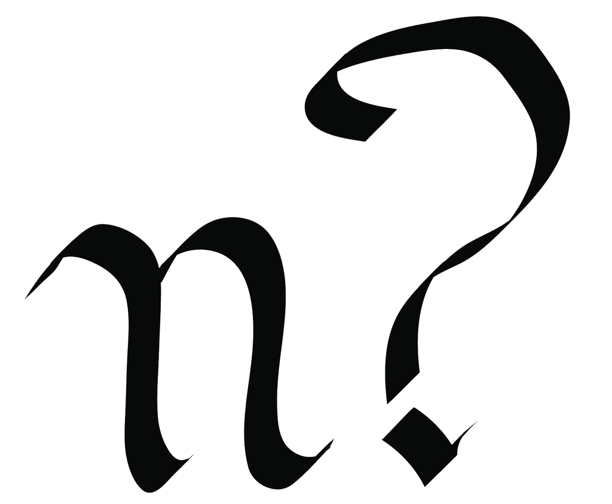

fig7: Ask a statistician about sample size, they will always tell you they need more data. The larger the sample size, the more sensitive the results. However lab work is expensive, so there is a tricky cost-benefit tradeoff to be considered. This is such an important problem that we have dedicated a whole chapter to it at the end of the book.

```r
pvec = rep(1/4, 4)
obsunder0 = rmultinom(1000, prob = pvec, size = 20)
dim(obsunder0)
```

```
[1]    4 1000
```

```r
obsunder0[, 1:11]
```

```
     [,1] [,2] [,3] [,4] [,5] [,6] [,7] [,8] [,9] [,10] [,11]
[1,]    5    3    8    7    5    5    4    3    4     4     3
[2,]    4    2    7    2    5    4    4    7    3     5     5
[3,]    5   10    3    8    8    6    5    8    7     3     9
[4,]    6    5    2    3    2    5    7    2    6     8     3
```

Creating a test - we need a **measure of variability**: sum of the squares of the differences btw. observed and expected values.

$$\begin{equation}
{\tt stat}=\frac{(E_A-x_A)^2}{E_A}+
\frac{(E_C-x_C)^2}{E_C}+
\frac{(E_G-x_G)^2}{E_G}+
\frac{(E_T-x_T)^2}{E_T}
=\sum_i\frac{(E_i-x_i)^2}{E_i}
\tag{1.1}
\end{equation}$$

```r
sum((obsunder0[, 1] - expected0)^2 / expected0)
```

```
[1] 0.4
```

[figure not shown]

```r
q95 = quantile(S0, probs = 0.95)
q95
```

```
95%
8.4
```

## Determining our test’s power

We must compute the probability that our test –based on the weighted sum-of-square differences– will detect that the data in fact do not come from the null hypothesis. We compute the probability of rejecting by simulation. We generate 1000 simulated instances from an alternative process, parameterized by pvecA.

```r
pvecA = c(3/8, 1/4, 3/12, 1/8)
observed = rmultinom(1000, prob = pvecA, size = 20)
dim(observed)
```

```
[1]    4 1000
```

```r
observed[, 1:7]
```

```
     [,1] [,2] [,3] [,4] [,5] [,6] [,7]
[1,]    7    9    7    7    7   10   11
[2,]    6    5    5    7    7    4    6
[3,]    3    3    6    4    5    4    1
[4,]    4    3    2    2    1    2    2
```

```r
apply(observed, 1, mean)
```

```
[1] 7.550 5.013 4.985 2.452
```

```r
expectedA = pvecA * 20
expectedA
```

```
[1] 7.5 5.0 5.0 2.5
```

```r
stat(observed[, 1])
```

```
[1] 2
```

```r
S1 = apply(observed, 2, stat)
q95
```

```
95%
8.4
```

```r
sum(S1 > q95)
```

```
[1] 160
```

```r
power = mean(S1 > q95)
power
```

```
[1] 0.16
```

$$P(\text{reject }H_0 \;|\; H_A)$$
Repeat with longer seq length to increase power:

```r
pvecA = c(3/8, 1/4, 3/12, 1/8)
observed = rmultinom(1000, prob = pvecA, size = 30)
S1 = apply(observed, 2, stat)
power = mean(S1 > q95)
power
```

[output not shown]

## Suggestions Exercises

**Exercise 1.8**

C. elegans genome nucleotide frequency: Is the mitochondrial sequence of C. elegans consistent with a model of equally likely nucleotides? a. Explore the nucleotide frequencies of chromosome M by using a dedicated function in the Biostrings package from Bioconductor.

2. Test whether the C. elegans data is consistent with the uniform model (all nucleotide fequencies the same) using a simulation. Hint: This is our opportunity to use Bioconductor for the first time. Since Bioconductor’s package management is more tightly controlled than CRAN’s, we need to use a special install function (from the BiocManager package) to install Bioconductor packages.

Alternative: ► Exercise 1.5

In the epitope example, use a simulation to find the probability of having a maximum of 9 or larger in 100 trials. How many simulations do you need if you would like to prove that “the probability is smaller than 0.000001”?